# Exploratory Analysis of Model Outputs

Yimeng Yin

July 07, 2015

# 100% Initial Funding

- M1-F100-1 100% initial Funding; No Smoothing
- M1-F100-2 100% initial Funding; Closed 10-year cd
- M1-F100-3 100% initial Funding; Closed 30-year cd
- M1-F100-4 100% initial Funding; Closed 30-year cp
- M1-F100-5 100% initial Funding; Open 30-year cp
- M1-F100-6 100% initial Funding; Full smoothing:open 30 year cp; 5-year asset smoothing

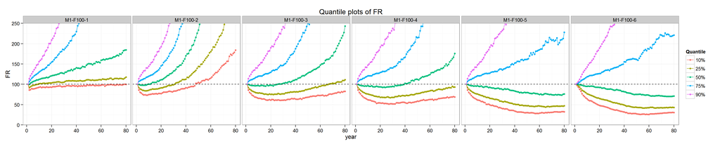

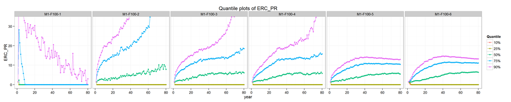

- M1-F100-6 100% initial Funding; Full smoothing:open 30 year cp; 5-year asset smoothing
- M1-F100-7 100% initial Funding; Full smoothing, DR 5.5%, ir 7.5%, sd 12%
- M1-F100-8 100% initial Funding; Full smoothing, DR 5.5%, ir 5.5%, sd 8%

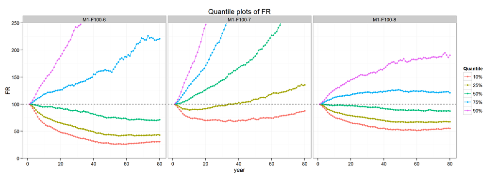

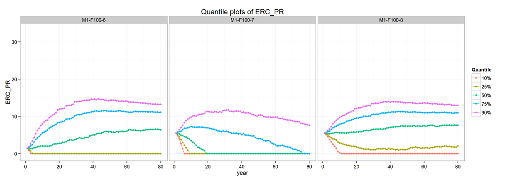

# 75% Initial Funding

- M1-F75-1 75% initial Funding; No Smoothing
- M1-F75-2 75% initial Funding; Closed 10-year cd
- M1-F75-3 75% initial Funding; Closed 30-year cd
- M1-F75-4 75% initial Funding; Closed 30-year cp
- M1-F75-5 75% initial Funding; Open 30-year cp
- M1-F75-6 75% initial Funding; Full smoothing:open 30 year cp; 5-year asset smoothing

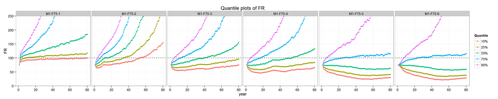

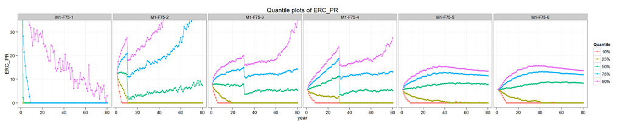

- M1-F75-6 75% initial Funding; Full smoothing:open 30 year cp; 5-year asset smoothing
- M1-F75-7 75% initial Funding; Full smoothing, DR 5.5%, ir 7.5%, sd 12%
- M1-F75-8 75% initial Funding; Full smoothing, DR 5.5%, ir 5.5%, sd 8%

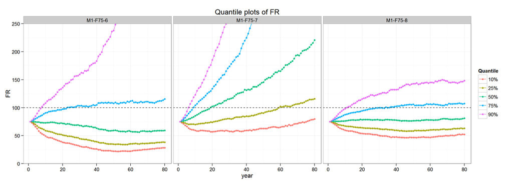

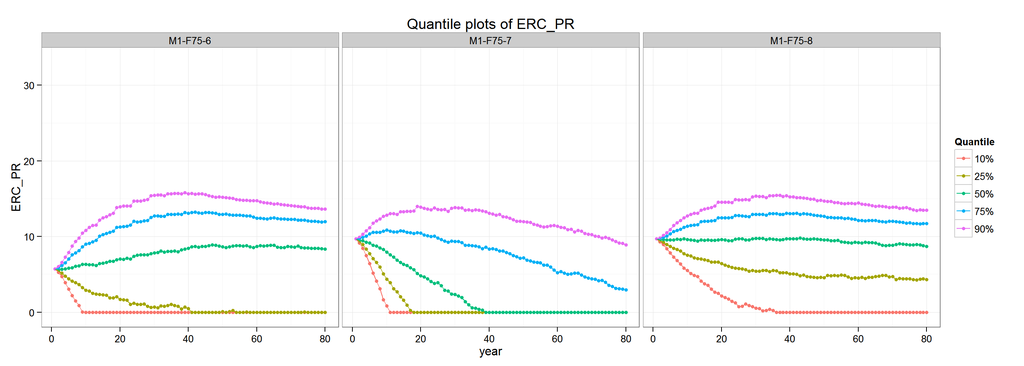

# BRP 100% Initial Funding

- M1-F100-6 100% initial Funding; Full smoothing:open 30 year cp; 5-year asset smoothing
- M1-F100-BRP1 100% initial Funding; BRP: open 15-year cp; 5-year asset smoothing, DR 7.5%, ir 7.5%, sd 12%
- M1-F100-BRP2 100% initial Funding; BRP: open 15-year cp; 5-year asset smoothing, DR 6.4%, ir 7.5%, sd 12%
- M1-F100-BRP3 100% initial Funding; Full smoothing:open 30 year cp; 5-year asset smoothing, ir 6.4%, sd 8%
- M1-F100-BRP4 100% initial Funding; BRP: open 15-year cp; 5-year asset smoothing, DR 7.5%, ir 6.4%, sd 8%
- M1-F100-BRP5 100% initial Funding; BRP: open 15-year cp; 5-year asset smoothing, DR 6.4%, ir 6.4%, sd 8%

Under stochastic return: mean = 7.5%, SD = 12% F100-6: full smoothing; 7.5% discount BRP1 : 15-year cp; discount rate 7.5%, BRP2 : 15-year cp; discount rate 6.4%.

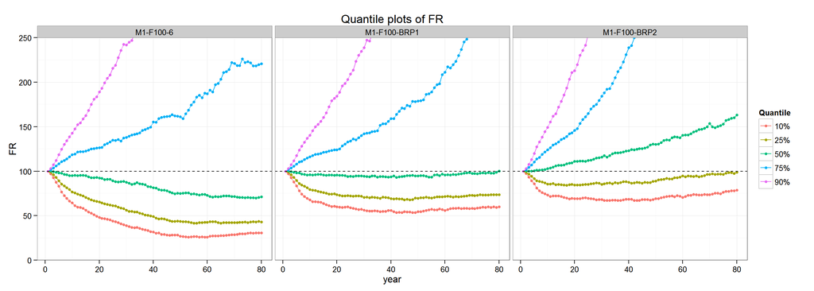

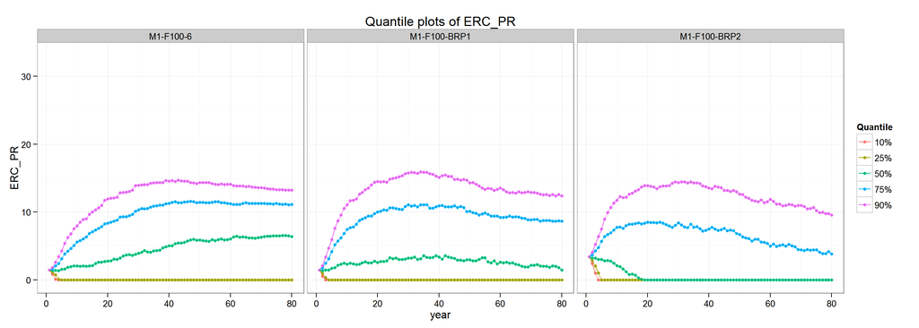

[figure not shown]

[figure not shown]

# BRP 75% Initial Funding

- M1-F75-6 75% initial Funding; Full smoothing:open 30 year cp; 5-year asset smoothing
- M1-F75-BRP1 75% initial Funding; BRP: open 15-year cp; 5-year asset smoothing, DR 7.5%, ir 7.5%, sd 12%
- M1-F75-BRP2 75% initial Funding; BRP: open 15-year cp; 5-year asset smoothing, DR 6.4%, ir 7.5%, sd 12%
- M1-F75-BRP3 75% initial Funding; Full smoothing:open 30 year cp; 5-year asset smoothing, ir 6.4%, sd 8%
- M1-F75-BRP4 75% initial Funding; BRP: open 15-year cp; 5-year asset smoothing, DR 7.5%, ir 6.4%, sd 8%
- M1-F75-BRP5 75% initial Funding; BRP: open 15-year cp; 5-year asset smoothing, DR 6.4%, ir 6.4%, sd 8%

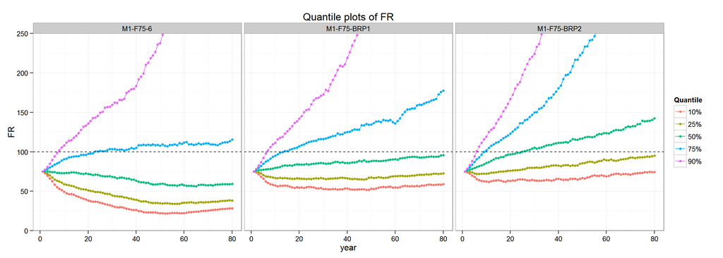

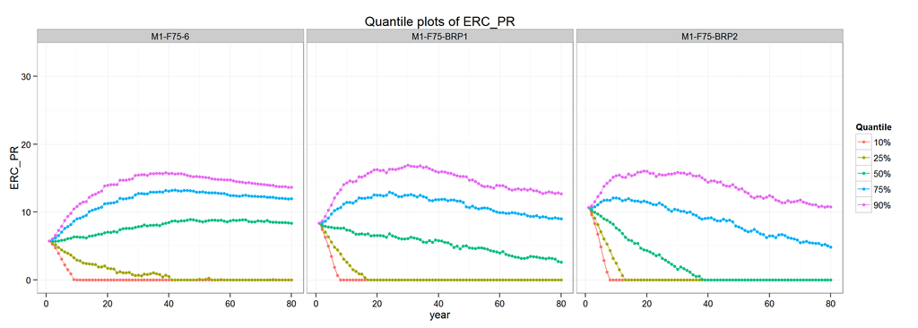

Under stochastic return: mean = 6.4%, SD = 8% BRP3 : Full smoothing; discount rate 7.5%, BRP4 : 15-year cp; discount rate 7.5%, BRP5 : 15-year cp; discount rate 6.4%.

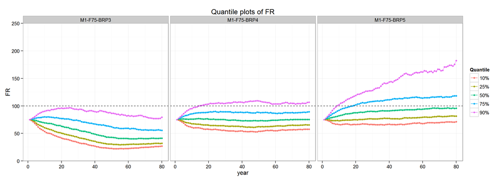

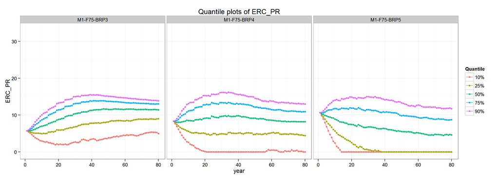